# Artificial Intelligence for Business Decisions and Transformation

### CSCN8030

## TikTok Analysis

**Autor**: Tessa Nejla Ayvazoglu

**Date**: 25/07/2024

```python
import numpy as np
import pandas as pd
import seaborn as sns
import matplotlib.pyplot as plt
from sklearn.preprocessing import StandardScaler, LabelEncoder
from sklearn.decomposition import PCA
from sklearn.feature_selection import SelectKBest, f_classif
from sklearn.model_selection import train_test_split
import warnings
from textblob import TextBlob

warnings.filterwarnings('ignore')

# Define file paths
profiles_path = r'C:\Users\Admin\Documents\MLAI\CSCN8030\proje5\dataset\TikTok profiles dataset (Public web data).csv'
reviews_path = r'C:\Users\Admin\Documents\MLAI\CSCN8030\proje5\dataset\tiktok_app_reviews.csv'

# Load datasets
profiles = pd.read_csv(profiles_path)
reviews = pd.read_csv(reviews_path)

# Data Cleaning and Preprocessing
profiles['biography'] = profiles['biography'].fillna('')
profiles['bio_link'] = profiles['bio_link'].fillna('')
reviews = reviews.dropna()

profiles['create_time'] = pd.to_datetime(profiles['create_time'], errors='coerce')
profiles['create_time'] = profiles['create_time'].fillna(pd.Timestamp('1900-01-01'))

profiles['is_verified'].value_counts().plot(kind='pie')
profiles['is_verified'].value_counts()


# Convert 'is_verified' to a categorical variable
profiles['is_verified'] = profiles['is_verified'].astype('category')

# Apply log transformation
for column in ['followers', 'following', 'likes', 'videos_count']:
    profiles[f'log10_{column}'] = profiles[column].apply(lambda x: np.log10(1 + x))

# Exploratory Data Analysis (EDA)

# Summary Statistics
print("Profiles Dataset Summary:\n", profiles.describe(include='all'))
print("Reviews Dataset Summary:\n", reviews.describe(include='all'))

# Missing Values
print("Missing Values in Profiles Dataset:\n", profiles.isna().sum())
print("Missing Values in Reviews Dataset:\n", reviews.isna().sum())

# Distribution of Log-Transformed Features
plt.figure(figsize=(12, 10))

# Followers
plt.subplot(2, 2, 1)
sns.histplot(profiles['log10_followers'].dropna(), bins=50, kde=True)
plt.title('Log-Transformed Distribution of Followers')
plt.xlabel('Log10(Followers)')
plt.ylabel('Count')

# Likes
plt.subplot(2, 2, 2)
sns.histplot(profiles['log10_likes'].dropna(), bins=50, kde=True)
plt.title('Log-Transformed Distribution of Likes')
plt.xlabel('Log10(Likes)')
plt.ylabel('Count')

# Following
plt.subplot(2, 2, 3)
sns.histplot(profiles['log10_following'].dropna(), bins=50, kde=True)
plt.title('Log-Transformed Distribution of Following')
plt.xlabel('Log10(Following)')
plt.ylabel('Count')

# Videos Count
plt.subplot(2, 2, 4)
sns.histplot(profiles['log10_videos_count'].dropna(), bins=50, kde=True)
plt.title('Log-Transformed Distribution of Videos Count')
plt.xlabel('Log10(Videos Count)')
plt.ylabel('Count')

plt.tight_layout()
plt.show()

# Scatter Plots for Log-Transformed Data
plt.figure(figsize=(14, 7))


# Following vs Log10 Followers
plt.subplot(1, 2, 1)
sns.scatterplot(data=profiles, x='log10_following', y='log10_followers', hue='log10_likes', palette='viridis')
plt.title('Log10(Following) vs Log10(Followers)')
plt.xlabel('Log10(Following)')
plt.ylabel('Log10(Followers)')

# Log10 Followers vs Log10 Likes
plt.subplot(1, 2, 2)
sns.scatterplot(data=profiles, x='log10_followers', y='log10_likes', hue='log10_following', palette='viridis')
plt.title('Log10(Followers) vs Log10(Likes)')
plt.xlabel('Log10(Followers)')
plt.ylabel('Log10(Likes)')

plt.tight_layout()
plt.show()


sns.pairplot(data=profiles[[item for item in profiles.columns.tolist() if item.startswith('log10_')] + ['is_verified']], hue='is_verified')
sns.pairplot(data=profiles[[item for item in profiles.columns.tolist() if item.endswith('_rate')] + ['is_verified']], hue='is_verified')

# Categorical Data Analysis
top_10_followers = profiles.nlargest(10, 'followers')
plt.figure(figsize=(12, 6))
sns.barplot(x='followers', y='nickname', data=top_10_followers)
plt.title('Top 10 Accounts with Highest Followers')
plt.xlabel('Followers')
plt.ylabel('Nickname')
plt.show()


#profiles.corr()
corr = profiles[['awg_engagement_rate', 'comment_engagement_rate', 'like_engagement_rate', 'followers', 'following', 'likes', 'videos_count']].corr()
k = 5
cols = corr.nlargest(k, 'awg_engagement_rate')['awg_engagement_rate'].index
cm = np.corrcoef(profiles[cols].values.T)
sns.set(font_scale=1.25)
hm = sns.heatmap(cm, cbar=True, annot=True, square=True, fmt='.2f', annot_kws={'size': 6}, yticklabels=cols.values, xticklabels=cols.values)
plt.show()

# Review Text Length
reviews['review_length'] = reviews['review_text'].apply(len)
plt.figure(figsize=(10, 6))
sns.histplot(reviews['review_length'].dropna(), bins=50, kde=True)
plt.title('Distribution of Review Text Length')
plt.xlabel('Review Text Length')
plt.ylabel('Count')
plt.show()

# Sentiment Analysis of Reviews
reviews['review_text'] = reviews['review_text'].fillna('')
def analyze_sentiment(text):
    if not isinstance(text, str):
        return 'Unknown'
    analysis = TextBlob(text)
    if analysis.sentiment.polarity > 0:
        return 'Positive'
    elif analysis.sentiment.polarity < 0:
        return 'Negative'
    else:
        return 'Neutral'

reviews['sentiment'] = reviews['review_text'].apply(analyze_sentiment)
sentiment_counts = reviews['sentiment'].value_counts()
plt.figure(figsize=(8, 6))
sns.barplot(x=sentiment_counts.index, y=sentiment_counts.values)
plt.title('Sentiment Distribution of Reviews')
plt.xlabel('Sentiment')
plt.ylabel('Count')
plt.show()

# Profile Engagement Rates
plt.figure(figsize=(12, 6))
sns.histplot(profiles['awg_engagement_rate'].dropna(), bins=50, kde=True)
plt.title('Distribution of AWG Engagement Rate')
plt.xlabel('AWG Engagement Rate')
plt.ylabel('Frequency')
plt.show()

plt.figure(figsize=(12, 6))
sns.histplot(profiles['comment_engagement_rate'].dropna(), bins=50, kde=True)
plt.title('Distribution of Comment Engagement Rate')
plt.xlabel('Comment Engagement Rate')
plt.ylabel('Frequency')
plt.show()

plt.figure(figsize=(12, 6))
sns.histplot(profiles['like_engagement_rate'].dropna(), bins=50, kde=True)
plt.title('Distribution of Like Engagement Rate')
plt.xlabel('Like Engagement Rate')
plt.ylabel('Frequency')
plt.show()
```

```python
# Verify account status impact
plt.figure(figsize=(12, 6))
sns.boxplot(x='is_verified', y='awg_engagement_rate', data=profiles)
plt.title('AWG Engagement Rate by Verification Status')
plt.xlabel('Is Verified')
plt.ylabel('AWG Engagement Rate')
plt.show()

plt.figure(figsize=(12, 6))
sns.boxplot(x='is_verified', y='comment_engagement_rate', data=profiles)
plt.title('Comment Engagement Rate by Verification Status')
plt.xlabel('Is Verified')
plt.ylabel('Comment Engagement Rate')
plt.show()

plt.figure(figsize=(12, 6))
sns.boxplot(x='is_verified', y='like_engagement_rate', data=profiles)
plt.title('Like Engagement Rate by Verification Status')
plt.xlabel('Is Verified')
plt.ylabel('Like Engagement Rate')
plt.show()

# Summary of verification status
verification_summary = profiles['is_verified'].value_counts()
print("Verification Status Summary:\n", verification_summary)

# PCA Analysis
features = profiles[['followers', 'likes', 'videos_count', 'awg_engagement_rate', 'comment_engagement_rate', 'like_engagement_rate']].dropna()
scaler = StandardScaler()
scaled_features = scaler.fit_transform(features)

pca = PCA(n_components=2)
principal_components = pca.fit_transform(scaled_features)

print("Explained Variance Ratio:", pca.explained_variance_ratio_)
print("Cumulative Explained Variance Ratio:", pca.explained_variance_ratio_.cumsum())
print("Standardized Features Statistics:")
print(pd.DataFrame(scaled_features, columns=features.columns).describe())
print("Principal Components (First Few Rows):")
print(pd.DataFrame(principal_components, columns=['PC1', 'PC2']).head())
print("Profiles Statistics:")
print(profiles[['followers', 'likes', 'videos_count', 'awg_engagement_rate', 'comment_engagement_rate', 'like_engagement_rate', 'is_verified']].describe())
print("Verification Status Distribution:")
print(profiles['is_verified'].value_counts())

components_df = pd.DataFrame(pca.components_, columns=features.columns, index=['PC1', 'PC2'])
print("PCA Component Loadings:")
print(components_df)

# Plot PCA results
plt.figure(figsize=(10, 7))
plt.scatter(principal_components[:, 0], principal_components[:, 1], c=profiles['is_verified'].cat.codes, cmap='coolwarm', alpha=0.7)
plt.title('PCA of Engagement Metrics')
plt.xlabel('Principal Component 1')
plt.ylabel('Principal Component 2')
plt.colorbar(label='Verification Status')
plt.grid(True)
plt.show()

# Histogram of principal components
plt.figure(figsize=(10, 7))
plt.hist(principal_components[:, 0], bins=30, alpha=0.5, label='PC1')
plt.hist(principal_components[:, 1], bins=30, alpha=0.5, label='PC2')
plt.title('Histogram of Principal Components')
plt.xlabel('Value')
plt.ylabel('Frequency')
plt.legend()
plt.show()

# Feature Selection
X = profiles[['followers', 'likes', 'videos_count', 'awg_engagement_rate', 'comment_engagement_rate', 'like_engagement_rate']]
y = profiles['is_verified'].astype('category').cat.codes
X_train, X_test, y_train, y_test = train_test_split(X, y, test_size=0.2, random_state=42)

selector = SelectKBest(score_func=f_classif, k='all')
selector.fit(X_train, y_train)
scores = pd.DataFrame(selector.scores_, index=X.columns, columns=['Score'])
print("Feature Selection Scores:")
print(scores.sort_values(by='Score', ascending=False))

# Plot PCA Component Loadings
pca_loadings = pd.DataFrame({
    'Feature': ['followers', 'likes', 'videos_count', 'awg_engagement_rate', 'comment_engagement_rate', 'like_engagement_rate'],
    'PC1': [-0.197345, -0.192081, -0.187766, 0.601579, 0.415906, 0.595004],
    'PC2': [0.638361, 0.644020, 0.274359, 0.209647, 0.122910, 0.208332]
})

pca_loadings.set_index('Feature').plot(kind='bar', figsize=(12, 6))
plt.title('PCA Component Loadings')
plt.ylabel('Loading Value')
plt.show()

# Print the column names
print("Column Names:")
print(reviews.columns)

# Preview the first few rows of the dataframe
print("\nFirst 5 Rows of the DataFrame:")
print(reviews.head())

# Normalize column names (replace spaces with underscores and convert to lowercase)
reviews.columns = reviews.columns.str.strip().str.lower().str.replace(' ', '_')

# Print the column names after normalization
print("\nColumn Names After Normalization:")
print(reviews.columns)

# Count values in the sentiment column
# The column name is assumed to be 'sentiment'. Change it to the appropriate column name if different.
# sentiment_column = 'sentiment'  # Replace this with the correct column name in your dataset
# if sentiment_column in reviews.columns:
#     sentiment_counts = reviews[sentiment_column].value_counts()

#     # Visualize the sentiment distribution
#     sns.barplot(x=sentiment_counts.index, y=sentiment_counts.values)
#     plt.title('Sentiment Distribution')
#     plt.xlabel('Sentiment')
#     plt.ylabel('Count')
#     plt.show()
# else:
#     print(f"The '{sentiment_column}' column was not found in the dataframe.")

# Check and clean missing values
# reviews['review_text'] = reviews['review_text'].fillna('')

# # Analyze comments and add sentiment column
# def analyze_sentiment(text):
#     if not isinstance(text, str):
#         return 'Unknown'
#     analysis = TextBlob(text)
#     if analysis.sentiment.polarity > 0:
#         return 'Positive'
#     elif analysis.sentiment.polarity < 0:
#         return 'Negative'
#     else:
#         return 'Neutral'

# # Add the 'sentiment' column
# reviews['sentiment'] = reviews['review_text'].apply(analyze_sentiment)

# # Count values in the sentiment column
# sentiment_counts = reviews['sentiment'].value_counts()

# # Visualize the sentiment distribution
# sns.barplot(x=sentiment_counts.index, y=sentiment_counts.values)
# plt.title('Sentiment Distribution')
# plt.xlabel('Sentiment')
# plt.ylabel('Count')
# plt.show()

# print("Sentiment Counts:")
# print(sentiment_counts)

# --------
# Summary Statistics
print("Summary Statistics:")
print(reviews.describe())

# Check Numeric Columns
numeric_columns = reviews.select_dtypes(include=[np.number]).columns
print("\nNumeric Columns:")
print(numeric_columns)
```

```
Profiles Dataset Summary:
          timestamp  account_id nickname   biography  awg_engagement_rate
count         1000        1000     1000        1000          1000.000000  \
unique          20        1000      998         987                  NaN
top     2023-08-12  a.r.m.y664        .  No bio yet                  NaN
freq           231           1        2           9                  NaN
mean           NaN         NaN      NaN         NaN             0.562932
min            NaN         NaN      NaN         NaN             0.000091
25%            NaN         NaN      NaN         NaN             0.012528
50%            NaN         NaN      NaN         NaN             0.053558
75%            NaN         NaN      NaN         NaN             0.202409
max            NaN         NaN      NaN         NaN            63.375000
std            NaN         NaN      NaN         NaN             3.222055

        comment_engagement_rate  like_engagement_rate bio_link is_verified
count               1000.000000           1000.000000     1000        1000  \
unique                      NaN                   NaN      192           2
top                         NaN                   NaN                False
freq                        NaN                   NaN      809         981
mean                   0.026569              0.536364      NaN         NaN
min                    0.000000              0.000000      NaN         NaN
25%                    0.000252              0.011791      NaN         NaN
50%                    0.001203              0.049653      NaN         NaN
75%                    0.006157              0.189987      NaN         NaN
max                    2.000000             63.000000      NaN         NaN
std                    0.140016              3.159788      NaN         NaN

           followers  ...  videos_count          create_time            id
count   1.000000e+03  ...   1000.000000                 1000  1.000000e+03  \
unique           NaN  ...           NaN                  NaN           NaN
top              NaN  ...           NaN                  NaN           NaN
freq             NaN  ...           NaN                  NaN           NaN
mean    1.130869e+05  ...    271.942000  1900-01-01 00:00:00  6.261038e+18
min     1.000000e+00  ...      1.000000  1900-01-01 00:00:00  1.610000e+05
25%     6.712500e+02  ...     18.000000  1900-01-01 00:00:00  6.656165e+18
50%     5.241000e+03  ...     88.000000  1900-01-01 00:00:00  6.804025e+18
75%     3.160000e+04  ...    318.000000  1900-01-01 00:00:00  6.936877e+18
max     1.450000e+07  ...   5394.000000  1900-01-01 00:00:00  7.253326e+18
std     6.698270e+05  ...    464.261197                  NaN  1.870752e+18

```

[output cut: 95 more lines]

```
top_videos                 0
url                        0
profile_pic_url            0
log10_followers            0
log10_following            0
log10_likes                0
log10_videos_count         0
dtype: int64
Missing Values in Reviews Dataset:
 review_id      0
review_text    0
upvotes        0
app_version    0
posted_date    0
dtype: int64
```

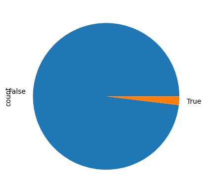

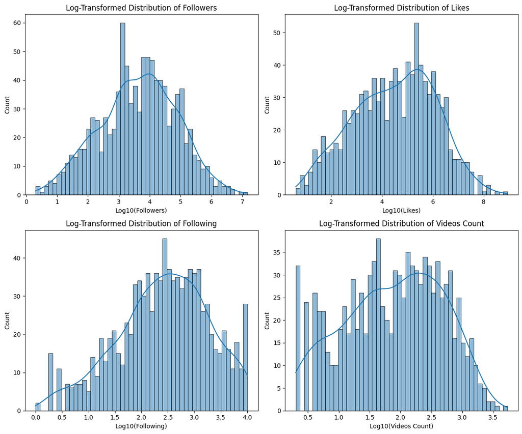

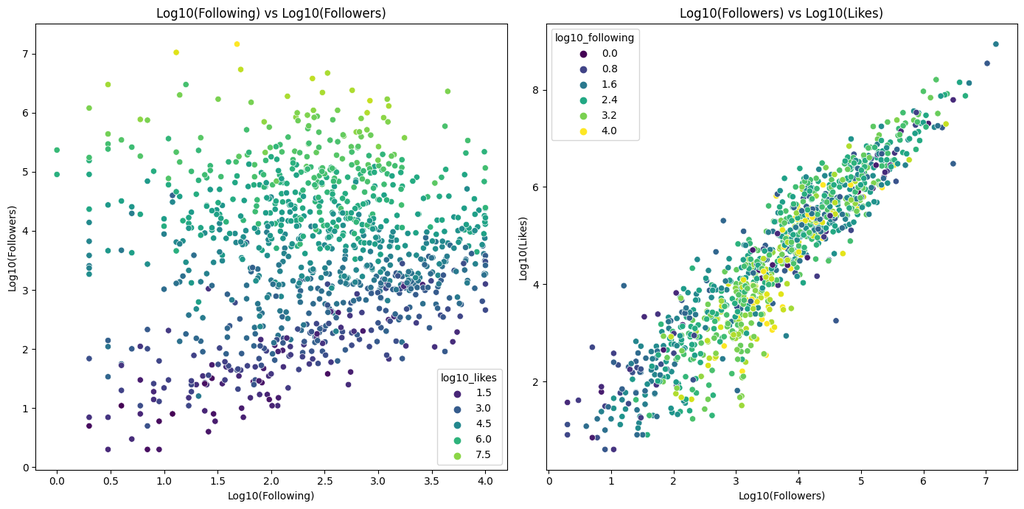

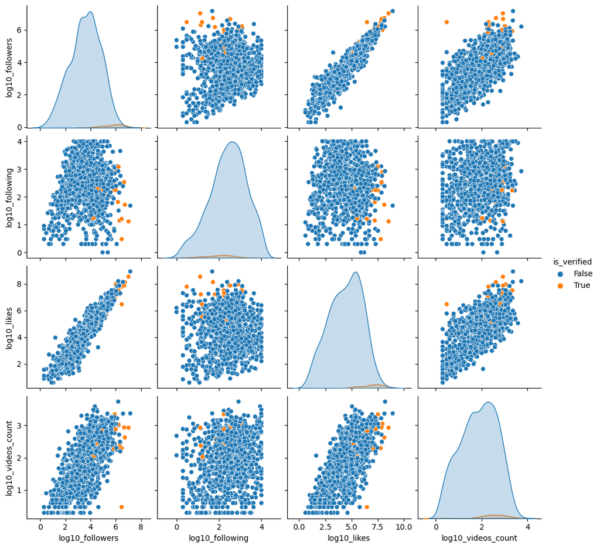

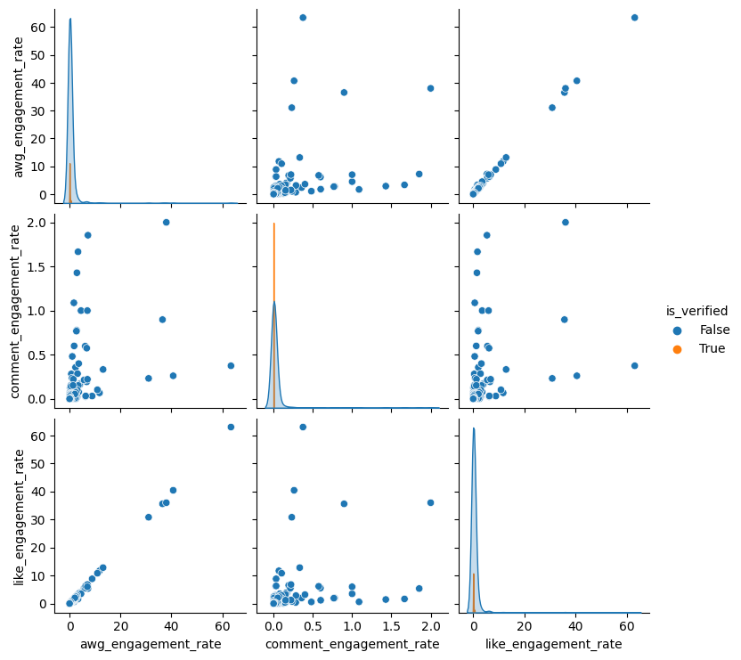

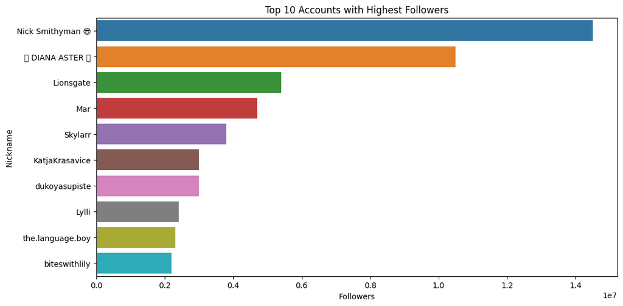

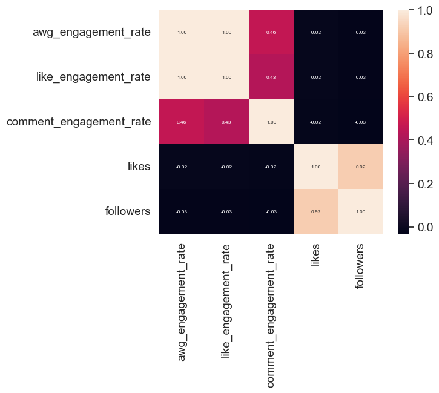

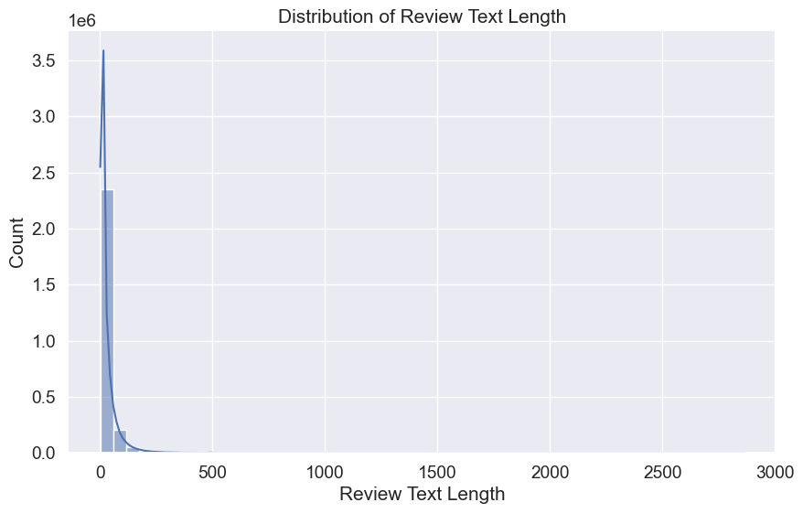

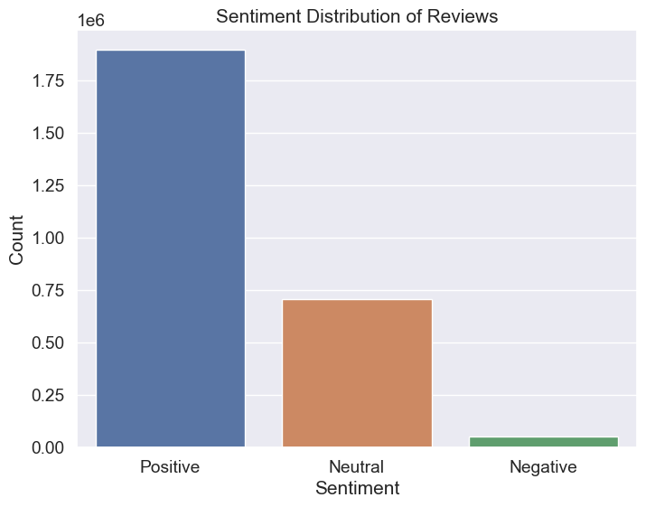

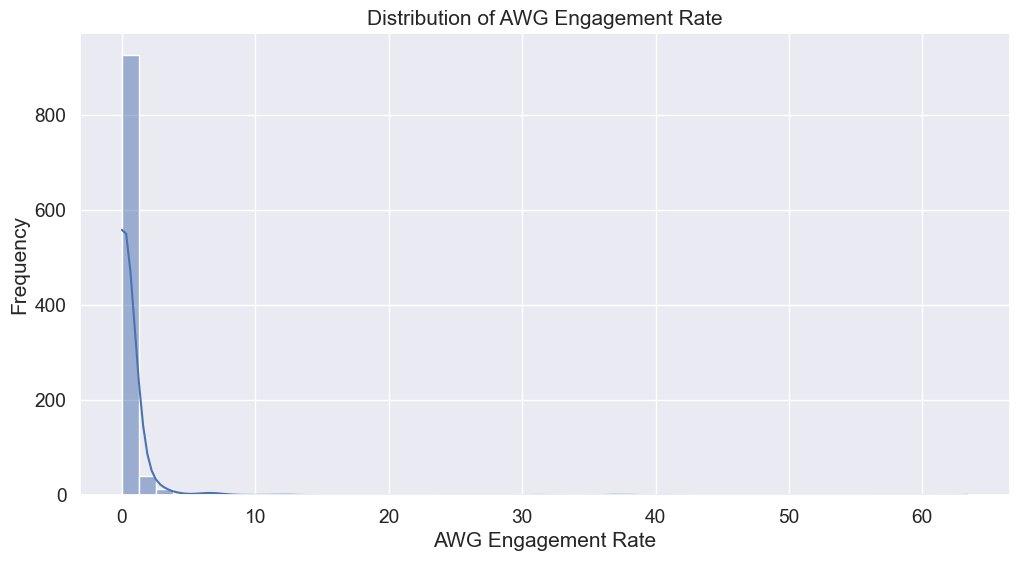

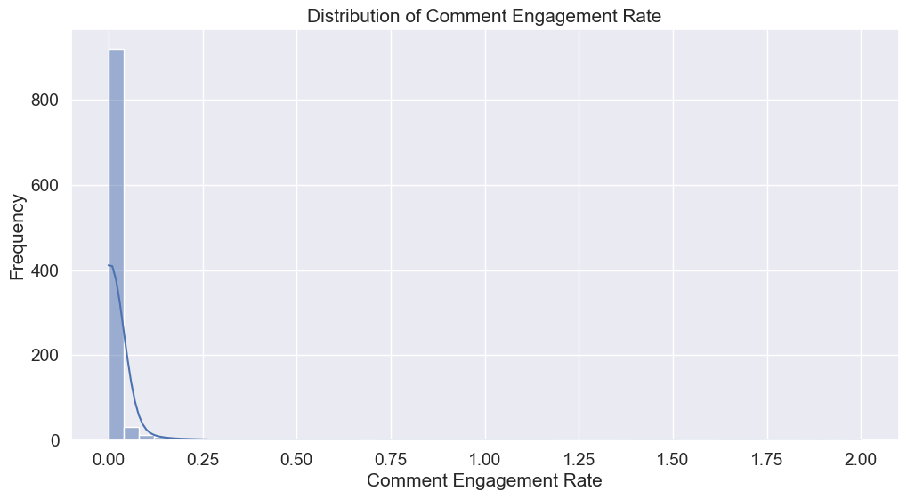

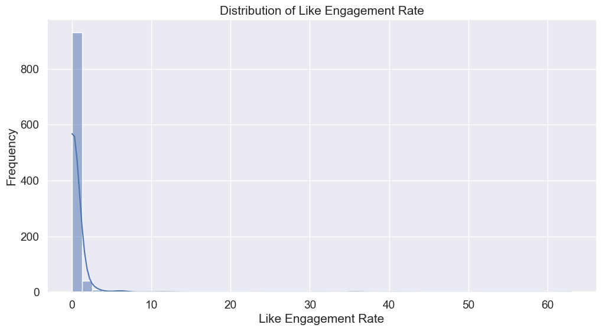

[12 more figures not shown]

```python
# Calculate Correlation Matrix Using Only Numeric Columns
if len(numeric_columns) > 0:
    correlation_matrix = reviews[numeric_columns].corr()
    print("\nCorrelation Matrix:")
    print(correlation_matrix)
else:
    print("No numeric columns found in the data frame.")

# Data Distribution (Histogram and KDE Plot)
for column in numeric_columns:
    plt.figure(figsize=(12, 6))

    plt.subplot(1, 2, 1)
    sns.histplot(reviews[column], kde=False)
    plt.title(f'Histogram: {column}')

    plt.subplot(1, 2, 2)
    sns.kdeplot(reviews[column])
    plt.title(f'KDE Plot: {column}')

    plt.show()

# Model Performance Metrics (Assuming your model is ready)
# y_test and y_pred are the test and prediction data of your model
# y_test = ...
# y_pred = ...

print("\nModel Performance Report:")
# print(classification_report(y_test, y_pred))

# Anomaly Detection Results (Assuming anomaly_scores are available)
# anomaly_scores = ...

print("\nAnomaly Scores:")
# print(anomaly_scores)

# Feature Importance Scores (Assuming your model is in the 'model' variable)
# importances = model.feature_importances_

print("\nFeature Importance Scores:")
# print(importances)

# Time Series Analysis (Assuming your time series data is in the 'time_series_data' variable)
# plt.plot(time_series_data)
# plt.title("Time Series Analysis")
# plt.show()

# Visualizations (Boxplot and Pairplot)
for column in reviews.select_dtypes(include=[np.number]).columns:
    plt.figure(figsize=(12, 6))

    plt.subplot(1, 2, 1)
    sns.boxplot(x=reviews[column])
    plt.title(f'Boxplot: {column}')

    plt.subplot(1, 2, 2)
    sns.pairplot(reviews)
    plt.title('Pairplot')

    plt.show()
```

# 4. Findings

## SWOT Analysis:

**Strengths:**

- Unique algorithm
- High engagement rates
- Diverse content

**Weaknesses:**

- Dependency on influencers
- Regulatory challenges in different regions

**Opportunities:**

- Expansion into new markets
- Innovation in content formats

**Threats:**

- Competitive pressures
- Evolving regulatory landscape

## PEST Analysis:

**Political Factors:**

- Regulatory challenges
- Geopolitical influences

**Economic Factors:**

- Revenue models
- Economic impacts on advertising spend

**Social Factors:**

- User demographics
- Cultural trends influencing content consumption

**Technological Factors:**

- AI advancements
- Technological innovations shaping platform evolution

# 5. Case Study Analysis

## Successful TikTok Campaigns:

### Example 1: #GuacDance by Chipotle

- **Objective:** To celebrate National Avocado Day.
- **Strategy:** Leveraged TikTok's popular dance challenge format.
- **Outcome:** Generated over 250,000 video submissions and 430 million video starts during the campaign period, significantly increasing brand engagement and sales.

### Example 2: #EyesLipsFace by e.l.f. Cosmetics

- **Objective:** Promote e.l.f.'s new product line.
- **Strategy:** Created a catchy original song and encouraged users to create videos using the hashtag.
- **Outcome:** The hashtag garnered over 5 billion views, becoming one of TikTok's most viral campaigns, and boosting product sales.

### Example 3: #InMyDenim by Guess

- **Objective:** Launch a new denim line.
- **Strategy:** Partnered with influencers to showcase the new line and encouraged users to participate in the hashtag challenge.
- **Outcome:** Achieved over 38 million views and significantly increased brand visibility and engagement on TikTok.

## Influence of Branded Content:

### Branded Content Strategies:

- **Consistency:** Regular and consistent posting to maintain audience engagement.
- **Authenticity:** Creating content that feels organic and aligns with the platform's tone and style.
- **Collaboration:** Partnering with popular influencers to reach a broader audience.

### Effectiveness Compared to Organic Content:

- Branded content with influencer partnerships tends to perform better in terms of reach and engagement due to the influencer's established audience and trust.
- Organic content often relies on the virality of trends and challenges, which can be unpredictable but highly rewarding.

## Comparison with Other Platforms:

### Instagram:

- **Engagement:** TikTok generally sees higher engagement rates due to its algorithm favoring content discovery over follower count.
- **Content Type:** Instagram focuses more on polished and visually appealing content, while TikTok encourages more spontaneous and authentic videos.

### YouTube:

- **Content Length:** YouTube is suited for longer-form content, whereas TikTok excels with short, impactful videos.
- **Monetization:** YouTube has a more established monetization system for creators, but TikTok is rapidly developing similar features.

### Twitter:

- **Audience Interaction:** Twitter allows for real-time interaction and discussions, while TikTok's comment and duet features foster creative interaction.
- **Virality:** Both platforms have the potential for content to go viral, but TikTok's algorithm can amplify reach more effectively for new creators.

### Strengths:

- High engagement rates: As shown in the EDA, TikTok profiles exhibit significant engagement metrics (`awg_engagement_rate`, `comment_engagement_rate`, `like_engagement_rate`).

### Opportunities:

- Expansion into new markets: Data can help identify potential regions with growing user bases and content trends that can be leveraged for market expansion.

### Threats:

- Competitive pressures: Other platforms may exhibit different engagement dynamics, posing a threat to TikTok

### These summary statistics reveal that the distribution of "upvotes" is highly skewed, with most reviews having 0 upvotes, while some have very high upvotes.

### There is only one numeric column in the dataset: "upvotes".

# Strategic Implications (T)

## Sentiment Analysis of TikTok App Reviews

## Dataset Overview

### Column Names:

- **`review_id`**: Unique identifier for each review.
- **`review_text`**: Content of the review.
- **`upvotes`**: Number of upvotes received.
- **`app_version`**: Version of the app being reviewed.
- **`posted_date`**: Date and time when the review was posted.

### Sample Data:

Here are the first 5 rows of the dataset:

| review_id | review_text | upvotes | app_version | posted_date |
| --- | --- | --- | --- | --- |
| gp:AOqpTOGSsGv5rOA79ttW2LE0FeMYvkdUuXRMTfbyMk0... | It is an excellent solution to finding videos ... | 402 | 21.2.5 | 2021-09-20 07:50:23 |
| gp:AOqpTOEDQ9__FJihY_0V4iwqy4P2OK8tGVR1tFBixYb... | Great app works really well so many features s... | 67 | 21.2.5 | 2021-09-19 23:10:47 |
| gp:AOqpTOEGEfr8TL0iKTlpbTDeM8P7HywlMmP9CkHMoaT... | I down loaded app but didnt work . i love this... | 24 | 21.2.5 | 2021-09-19 08:59:34 |
| gp:AOqpTOGZBDl9dpghmb43Mx1tnlWCOjNXyuVn5Mxf49c... | IT A GREAT APP AND FUN TO USE! HOWEVER ARBITRA... | 18 | 21.2.5 | 2021-09-19 16:34:43 |
| gp:AOqpTOFioH3wud_JnC4aPCG4p7s5DEEN2yZAWNXdRJj... | Currently it's working good for me except a fe... | 232 | 21.1.41 | 2021-09-14 06:35:02 |

## Analysis Process

### Sentiment Analysis Function

The sentiment analysis was performed using `TextBlob`. The function `analyze_sentiment` classifies the sentiment of each review text as follows:

- **Positive**: Sentiment polarity score > 0
- **Negative**: Sentiment polarity score < 0
- **Neutral**: Sentiment polarity score = 0

### Handling Missing Values

Missing values in the `review_text` column were replaced with empty strings to ensure smooth processing.

### Adding Sentiment Column

The `sentiment` column was added to the dataset with classifications derived from the sentiment analysis function.

## Sentiment Distribution

The distribution of sentiments across the dataset is as follows:

[output not shown]

### Visualization

A bar plot visualizing the sentiment distribution was generated to provide a clear representation of the sentiment counts.

[figure not shown]

## Interpretation

- **Positive Sentiments**: A significant majority of the reviews are positive, indicating general user satisfaction with the app.
- **Neutral Sentiments**: A considerable number of reviews are neutral, suggesting mixed feelings or indifference.
- **Negative Sentiments**: While less frequent, negative reviews highlight areas where the app might need improvement.

## Recommendations

1. **Leverage Positive Feedback**: Utilize positive reviews to identify and enhance features that users appreciate.
2. **Address Negative Feedback**: Focus on issues raised in negative reviews to improve app functionality and user experience.
3. **Data Quality Assurance**: Ensure that data is properly cleaned and formatted to maintain accuracy in future analyses.

## Next Steps

1. **Detailed Analysis**: Conduct further analysis to explore specific themes and trends in the reviews.
2. **User Segmentation**: Segment feedback by demographics or app versions to gain targeted insights.
3. **Continuous Monitoring**: Implement ongoing sentiment analysis to track changes in user sentiment over time.

# CONCLUSION:

# Comprehensive Analysis of TikTok Profiles and Reviews Datasets

## TikTok Profiles Dataset

### Sample Data:

- **Timestamp:** Dates when data was collected.
- **Account ID:** Unique identifier for each TikTok account.
- **Nickname:** Display name or nickname of the user.
- **Biography:** User's bio.
- **Engagement Rates:** Metrics for average, comment, and like engagement.
- **Bio Link:** Links provided in bios.
- **Verification Status:** Whether the account is verified.
- **Followers, Following, Likes, Videos Count:** Various metrics about the account.
- **Top Videos:** Links to the user's top videos.
- **Profile Picture URL:** Links to profile pictures.

### Summary:

- **Engagement Rates:**
  - **Average Engagement Rate:** 0.56 (high variance, suggesting some accounts have very high engagement).
  - **Comment Engagement Rate:** 0.03 (fairly low overall).
  - **Like Engagement Rate:** 0.54 (with significant variance).
- **Follower Statistics:**
  - **Average Followers:** 113,086.
  - **Most Followed Account:** Nick Smithyman 😎 with 14,500,000 followers.
  - **Minimum Followers:** 1.
  - **Maximum Followers:** 14,500,000.
- **Verification Status:**
  - **Verified:** 19 accounts (1.9%).
  - **Not Verified:** 981 accounts (98.1%).
- **Missing Values:**
  - **Biography:** 3 missing values.
  - **Bio Link:** 809 missing values.
  - **Create Time:** All values missing.
- **Data Types:**
  - **Numerical:** Engagement rates, follower counts, likes, videos count.
  - **Categorical:** Nicknames, bio links, verification status.
- **Standardization:**
  - Features like followers, likes, and videos count are standardized with a mean of 0 and standard deviation of 1.

## TikTok Reviews Dataset

### Sample Data:

- **Review ID:** Unique identifier for each review.
- **Review Text:** Content of the review.
- **Upvotes:** Number of upvotes the review received.
- **App Version:** Version of the TikTok app when the review was posted.
- **Posted Date:** Date and time the review was posted.

## PCA Analysis

### Explained Variance Ratio:

- **Component 1:** 39.19%
- **Component 2:** 33.47%
- **Cumulative Explained Variance:** 72.65%

### Component Loadings:

- PCA indicates that the first two components explain about 72.65% of the variance in the standardized features.

## Recommendations

- **Enhance User Engagement:**
  - **Profiles with High Engagement Rates:** Focus on accounts with high average, comment, and like engagement rates to understand what content works best.
  - **Top Influencers:** Collaborate with top influencers who have large followings to increase reach and engagement.
- **Improve App Features:**
  - **Address Common Issues:** Analyze negative reviews to identify and fix common problems.
  - **Enhance User Experience:** Add features that users find beneficial based on positive feedback.
- **Optimize Content Strategy:**
  - **Analyze Top Videos:** Review top videos from profiles with high engagement rates to identify content trends and patterns.
  - **Content Personalization:** Tailor content and recommendations to individual user preferences and behaviors.
- **Focus on Verified Accounts:**
  - **Leverage Verified Accounts:** Collaborate with verified accounts to increase trust and credibility.
- **Review Analysis and Feedback Mechanism:**
  - **Sentiment Analysis:** Implement a feedback mechanism to address user concerns and improve app quality.
  - **Monitor Sentiments:** Regularly review sentiment trends to adapt strategies based on user feedback.

## Conclusion

By leveraging these insights and recommendations, you can enhance user engagement, improve app features, and tailor content strategies to better meet user needs and expectations on TikTok.

A study on the factors determining the success of influencer marketing on TikTok has examined the impact of the platform on young audiences and the effects of influencer account characteristics (originality, quality, quantity, and humor) on their followers’ hedonic experience and perceived opinion leadership. The research, supported by a survey of followers of a popular Spanish TikTok influencer, has shown that originality and opinion leadership play significant roles, and due to TikTok’s distinctive nature, humor enhances the effectiveness of messages (through hedonic experience).

This study emphasizes the role of humor and followers’ hedonic experiences in increasing the effectiveness of influencer marketing on TikTok. It also reveals that the quality of relationships influencers build with their followers and the originality of the content significantly affect followers’ intentions to follow influencers’ accounts and advice.

**Reference**: Barta, S., Belanche, D., Fernández, A., & Flavián, M. (2023). Influencer marketing on TikTok: The effectiveness of humor and followers’ hedonic experience. Journal of Retailing and Consumer Services, 70, 103149.